# The Linguistic Trajectories of Presidential Candidates

### Polls, Primaries, and making sense of it all

How could we get a peek at the discursive dynamics in play? One way to study the discourse in a field is to think about the frames of reference that elites communicate to the citizenry[^2]. Most citizens first encounter concepts in the space—candidates, issues, events—through elite communication of some sort, whether through traditional channels like news media or more contemporary ones like social media. These concepts then take on a life of their own, with the meanings used to frame them evolving once individuals interpret and deploy them. Still, looking at the frames used in media gives a good estimate of the discursive space.

So, we want to study the relevant concepts being used in the field and their meanings as the electoral cycle is in full throttle. In a context with so many moving parts, what are the meanings and narratives that citizens can use to make sense of the field? A La Carte (ALC) Embeddings are a good tool to explore this puzzle.

I used this as an opportunity to practice using word embeddings and teach myself some more methods. I leave the code used to train the model and develop the analysis in case anyone finds it useful.

### A word on word embeddings

So, if we want to see the frames of reference that people are being "offered" to navigate the political landscape, we could use ALC embeddings to look at the meanings associated with each candidate, how they relate to one another, and how they connect to salient issues.

[^1]: At the time of writing. March 4th, 2026

[^2]: J. Zaller (1992). The Nature and Origins of Mass Opinion

## Packages and helper functions

```python
import requests
from bs4 import BeautifulSoup
import time
from tqdm import tqdm
import pickle
import pandas as pd
import dateparser
import matplotlib.pyplot as plt
import re
from gensim.models import Word2Vec
import numpy as np
from collections import defaultdict
from sklearn.manifold import TSNE

def scrape_text(url):
    headers = {"User-Agent": "Mozilla/5.0 (Windows NT 10.0; Win64; x64) "
                  "AppleWebKit/537.36 (KHTML, like Gecko) "
                  "Chrome/122.0.0.0 Safari/537.36"}
    resp = requests.get(url, headers=headers, timeout=15)
    soup = BeautifulSoup(resp.content, 'html.parser')

    h1 = soup.find('h1', class_='Title ArticleHeader-Title')
    if not h1:
        return None, None, 'no_title'

    title = h1.get_text()

    ps = soup.find_all('p', class_=lambda c: c and 'font--secondary' in c)
    text = ' '.join([p.get_text() for p in ps if len(p.find_all('a')) == 0])

    if not text.strip():
        return title, '', 'paywall'

    return title, text, 'ok'

def get_articles_mentioning(candidate, df):
    mask = df['processed_body'].str.contains(candidate, na=False)
    return df[mask][['date', 'title', 'processed_body']]

def compute_context_vectors(sentences, wv, window=10):
    ctx_sum = defaultdict(lambda: np.zeros(wv.vector_size))
    ctx_count = defaultdict(int)
    for sent in tqdm(sentences):
        for i, word in enumerate(sent):
            if word not in wv:
                continue
            lo, hi = max(0, i - window), min(len(sent), i + window + 1)
            ctx_embeds = [wv[sent[j]] for j in range(lo, hi) if j != i and sent[j] in wv]
            if ctx_embeds:
                ctx_sum[word] += np.mean(ctx_embeds, axis=0)
                ctx_count[word] += 1

    return {w: ctx_sum[w] / ctx_count[w] for w in ctx_sum}

def get_monthly_context(candidate, month_texts, wv, window=10):
    ctx_sum = np.zeros(wv.vector_size)
    count = 0
    for text in month_texts:
        tokens = text.split()
        for i, token in enumerate(tokens):
            if token != candidate:
                continue
            lo, hi = max(0, i - window), min(len(tokens), i + window + 1)
            ctx_embeds = [wv[tokens[j]] for j in range(lo, hi) if j != i and tokens[j] in wv]
            if ctx_embeds:
                ctx_sum += np.mean(ctx_embeds, axis=0)
                count += 1
    return ctx_sum / count if count > 0 else None

def plot_trajectories(embeddings, title):
    all_embs, all_labels = [], []
    for candidate, months in embeddings.items():
        for month in sorted(months):
            all_embs.append(months[month])
            all_labels.append((candidate, month))

    all_embs = np.array(all_embs)
    coords = TSNE(
        n_components=2, perplexity=min(30, len(all_embs) - 1),
    ).fit_transform(all_embs)

    label_idx = {c: [] for c in candidates}
    for i, (c, _) in enumerate(all_labels):
        label_idx[c].append(i)

    colors = plt.cm.tab20(np.linspace(0, 1, len(candidates)))
    cmap = dict(zip(candidates.keys(), colors))

    fig, ax = plt.subplots(figsize=(14, 10))
    for candidate in candidates:
        idx = label_idx[candidate]
        if not idx:
            continue
        xs, ys = coords[idx, 0], coords[idx, 1]
        label = candidate.replace('_', ' ').title()
        ax.plot(xs, ys, '--o', color=cmap[candidate], label=label, alpha=0.9, markersize=5)
        last_month = str(all_labels[idx[-1]][1])
        ax.annotate(
            f"{label.split()[-1]} {last_month}", (xs[-1], ys[-1]),
            fontsize=6, color=cmap[candidate],
            bbox=dict(boxstyle='round,pad=0.2', facecolor='white', edgecolor='none', alpha=0.8),
        )

    ax.set_title(title)
    ax.set_xlabel('t-SNE 1')
    ax.set_ylabel('t-SNE 2')
    ax.legend(bbox_to_anchor=(1.05, 1), loc='upper left', fontsize=7)
    plt.tight_layout()
    plt.show()

def centroid(words):
    vecs = [w2v.wv[w] for w in words if w in w2v.wv]
    return np.mean(vecs, axis=0)
```

## Text processing

```
Loaded 12290 articles.
```

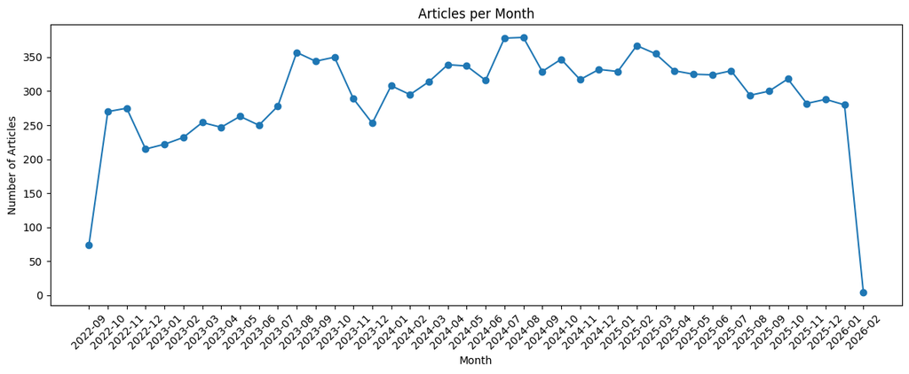

```python
with open("data/processed_arts.pkl", "rb") as f:
    arts = pickle.load(f)

print(f"Loaded {arts.shape[0]} articles.")

monthly_counts = arts.groupby('month').size()

fig, ax = plt.subplots(figsize=(12, 5))
ax.plot(range(len(monthly_counts)), monthly_counts.values, marker='o')
ax.set_xticks(range(len(monthly_counts)))
ax.set_xticklabels([str(p) for p in monthly_counts.index], rotation=45)
ax.set_xlabel('Month')
ax.set_ylabel('Number of Articles')
ax.set_title('Articles per Month')
plt.tight_layout()
plt.show()
```

Barring the first and last months of the period, we have a solid number of articles per month.

Before training the model we need to do some additional processing. The model only tracts individuals, so we need to turn candidate names (which are composed of many words) in single words. The best way to do so is to convert mentions of each candidate into `name_lastname` so that word2vec interprets it as a single word. For the sake of interpretability and my own sanity, I considered the candidates that are scheduled to participate in interparty consultation or those that poll *anything* in, at least, five [polls](https://es.wikipedia.org/wiki/Anexo:Sondeos_de_intenci%C3%B3n_de_voto_para_las_elecciones_presidenciales_de_Colombia_de_2026).

I process the text and look at how candidate mentions are distributed in the corpus over time.

```python
candidates = {"vicky_dávila": {"name" : "vicky", "last": "dávila"},
              "sergio_fajardo": {"name" : "sergio", "last": "fajardo"},
              "abelardo_de_la_espriella": {"name" : "abelardo de la", "last": "espriella"},
              "iván_cepeda": {"name" : "iván", "last": "cepeda"},
              "roy_barreras": {"name" : "roy", "last": "barreras"},
              "mauricio_cárdenas": {"name" : "mauricio", "last": "cárdenas"},
              "juan_fernando_cristo": {"name" : "juan fernando", "last": "cristo"},
              "juan_manuel_galán": {"name" : "juan manuel", "last": "galán"},
              "maria_fernanda_cabal": {"name" : "maria fernanda", "last": "cabal"},
              "claudia_lópez": {"name" : "claudia", "last": "lópez"},
              "david_luna": {"name" : "david", "last": "luna"},
              "juan_daniel_oviedo": {"name" : "juan daniel", "last": "oviedo"},
              "enrique_peñalosa": {"name" : "enrique", "last": "peñalosa"},
              "juan_carlos_pinzón": {"name" : "juan carlos", "last": "pinzón"},
              "daniel_quintero": {"name" : "daniel", "last": "quintero"},
              "camilo_romero": {"name" : "camilo", "last": "romero"},
              "paloma_valencia": {"name" : "paloma", "last": "valencia"}}

processed_arts = []
for _, art in arts.iterrows():

    # In each article, check for mentions of all candidates and replace them with the candidate key.
    p_art = art['body'].lower()
    for c in candidates:
        full_name = candidates[c]['name'] + ' ' + candidates[c]['last']
        if full_name in p_art or full_name in art['title'].lower():
            p_art = p_art.replace(full_name, c)
            p_art = re.sub(r'(?<![_\w])' + re.escape(candidates[c]['last']) + r'(?![_\w])', c, p_art)

    # Some additional cleaning to reduce noise in embeddings
    p_art = re.sub(r'[^\w\s]', ' ', p_art)
    p_art = re.sub(r'\b\d+\b', ' ', p_art)
    p_art = re.sub(r'\s+', ' ', p_art).strip()

    processed_arts.append(p_art)

arts['processed_body'] = processed_arts
```

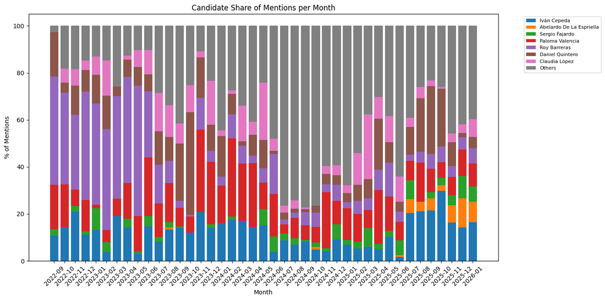

```python
# Counting mentions
mentions = []
for _, row in arts.iterrows():
    body = row['processed_body']
    for c in candidates:
        count = body.count(c)
        if count > 0:
            mentions.append({'candidate': c, 'month': row['month'], 'mentions': count})

mentions_df = pd.DataFrame(mentions)
mentions_monthly = mentions_df.groupby(['candidate', 'month'])['mentions'].sum().reset_index()
mentions_pivot = mentions_monthly.pivot(index='month', columns='candidate', values='mentions').fillna(0).astype(int)

# Looking at candidates that have a realistic chance of being in the first round ballot, grouping the rest as "others".

cands = ["iván_cepeda", "abelardo_de_la_espriella", "sergio_fajardo", "paloma_valencia",
         "roy_barreras", "daniel_quintero", "claudia_lópez"]

plot_df = mentions_pivot[cands].copy()
plot_df['Others'] = mentions_pivot.drop(columns=cands).sum(axis=1)
plot_pct = plot_df.div(plot_df.sum(axis=1), axis=0) * 100

cols = [c.replace('_', ' ').title() for c in cands] + ['Others']
plot_pct.columns = cols

fig, ax = plt.subplots(figsize=(14, 7))

x = range(len(plot_pct))
bottom = [0] * len(plot_pct)

for col in cols[:-1]:
    ax.bar(x, plot_pct[col].values, bottom=bottom, label=col)
    bottom = [b + v for b, v in zip(bottom, plot_pct[col].values)]

ax.bar(x, plot_pct['Others'].values, bottom=bottom, label='Others', color='grey')

ax.set_xticks(list(x))
ax.set_xticklabels([str(p) for p in plot_pct.index], rotation=45)
ax.set_xlabel('Month')
ax.set_ylabel('% of Mentions')
ax.set_title('Candidate Share of Mentions per Month')
ax.legend(bbox_to_anchor=(1.05, 1), loc='upper left', fontsize=8)
plt.tight_layout()
plt.show()
```

Interesting. For how strong he is polling, De la Espriella become relevant relatively recently. The optimist in me hopes this suggests that he will deflate soon. The rest of the top candidates are regular fixtures in the political field, so it is not surprising that they dominate in mentions.

## Word Embeddings

Model parameters are based on Rodríguez and Spirling (2022)[^3]

[^3]: Rodriguez, P. L., & Spirling, A. (2022). Word embeddings: What works, what doesn’t, and how to tell the difference for applied research. The Journal of Politics, 84(1), 101-115.

```python
sentences = [text.split() for text in arts['processed_body'].dropna()]

w2v = Word2Vec(sentences,
               vector_size=300,
               window=10,
               min_count=5,
               workers=4,
               epochs=15,
               sg=1)

w2v.save("data/w2v_elespectador.model")
print(f"Trained a model with vocabulary size: {len(w2v.wv)}")
```

```
Trained a model with vocabulary size: 26624
```

We can get an initial sense at the meaning given to candidates in the corpus by looking at the most similar words to each of them. We can see each candidate vector and the 8 with the highest cosine similarity in the vocabulary.

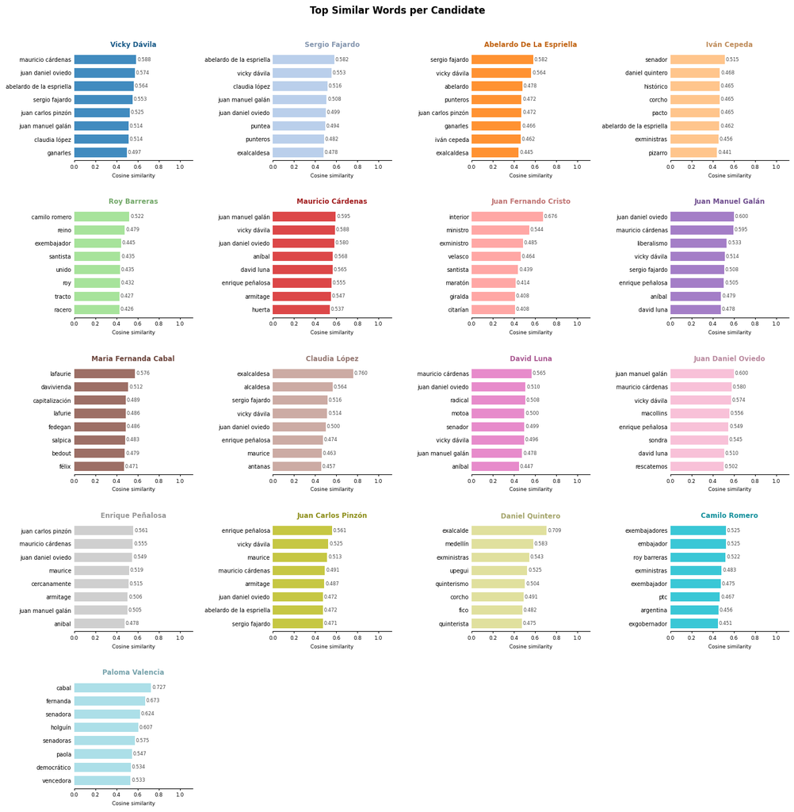

```python
spacing = 0.45

similar_words = {}
for c in candidates.keys():
    try:
        similar_words[c] = w2v.wv.most_similar(c, topn=8)
    except KeyError:
        pass

n_cols = 4
n_rows = -(-len(similar_words) // n_cols)

colors = plt.cm.tab20(np.linspace(0, 1, len(similar_words)))

fig, axes = plt.subplots(n_rows, n_cols, figsize=(14, n_rows * 2.8))
axes = axes.flatten()

for ax, (candidate, pairs), color in zip(axes, similar_words.items(), colors):
    words = [p[0].replace('_', ' ') for p in reversed(pairs)]
    scores = [p[1] for p in reversed(pairs)]
    y_pos = np.arange(len(words)) * spacing
    ax.barh(y_pos, scores, height=spacing * 0.7, color=color, edgecolor='none', alpha=0.85)
    for y, score in zip(y_pos, scores):
        ax.text(score + 0.01, y, f'{score:.3f}', va='center', fontsize=6, color='#444444')
    ax.set_yticks(y_pos)
    ax.set_yticklabels(words, fontsize=7)
    ax.set_xlim(0, 1.12)
    ax.set_ylim(y_pos[0] - spacing * 0.6, y_pos[-1] + spacing * 0.6)
    ax.set_title(candidate.replace('_', ' ').title(), fontsize=8.5, fontweight='bold',
                 color=color * np.array([0.75, 0.75, 0.75, 1]))
    ax.tick_params(axis='x', labelsize=6.5)
    ax.spines[['top', 'right', 'left']].set_visible(False)
    ax.tick_params(axis='y', length=0)
    ax.xaxis.set_tick_params(length=2)
    ax.set_xlabel('Cosine similarity', fontsize=6.5)

for ax in axes[len(similar_words):]:
    ax.set_visible(False)

fig.suptitle('Top Similar Words per Candidate', fontsize=12, fontweight='bold', y=1.01)
plt.tight_layout(h_pad=2.5, w_pad=1.5)
plt.show()
```

Again, some interesting stuff here but nothing super surprising. Candidate meanings seem to coalesce around each other as alliances and consultations pop up. This is particularly true for candidate that are polling low (See Vicky Dávila, Mauricio Cárdenas, Enrique Peñalosa, and other members of `La Gran Consulta por Colombia`).

It is not surprising that candidate vectors are similar to each other. Being candidates in a presidential election cycle is a big similarity between two concepts. This is a valid finding, but it does not say much about the frames of reference being used for candidates beyond "candidate." ALC embeddings allows us to dig deeper into candidate vectors and the discoursive space.

## ALC Embeddings

For every word $w$ in the vocabulary, compute its **context vector** $\bar{c}_w$ (average of its neighbours' embeddings over the full corpus). Then find the linear map $A$ such that $\bar{c}_w \cdot A \approx v_w$ via least squares. This transform can then embed *any* word—or a candidate in a specific time window—given only its context. This method has been show to produce high-quality embeddings for use cases such as this one[^6].

[^6]: Rodriguez, P. L., Spirling, A., & Stewart, B. M. (2023). Embedding regression: Models for context-specific description and inference. American Political Science Review, 117(4), 1255-1274.

```python
ctx_vecs = compute_context_vectors(sentences, w2v.wv)

# Fit A via least squares: C @ A ≈ E
print("Fitting ALC matrix A via least squares...")
words_fit = [w for w in ctx_vecs if w in w2v.wv]
C = np.array([ctx_vecs[w] for w in words_fit])
E = np.array([w2v.wv[w] for w in words_fit])

A, *_ = np.linalg.lstsq(C, E, rcond=None)
print(f"ALC matrix A learned from {len(words_fit)} words")
```

```
Fitting ALC matrix A via least squares...
ALC matrix A learned from 26624 words
```

Let's go back to the original question: How does the meaning that media gives to candidates change over a time period? using ALC embeddins, we can collect all context windows around each candidate-month pair token in that month's articles, average them into a single context vector, and apply $A$ to get the ALC embedding for that (candidate, month) pair. This time labelled embeddings are then a representation for the evolving meaning of candidate as the electoral cycle goes on.

To control for outlier months and reduce the noise in the model, I calculate each candidate-month embeddings as the rolling average of the last three months. This erases the uniqueness of each month, but it takes into account that candidate framings are given in context and usually respond to a larger window of considerations than a month. A more throughout analyzes would have to test the robustness of this transformation.

```python
# Raw monthly embeddings — keep every month that has at least one mention
monthly_alc_raw = {}
for candidate in tqdm(candidates):
    monthly_alc_raw[candidate] = {}
    for month, grp in arts.groupby('month'):
        texts = grp['processed_body'].dropna().tolist()
        ctx = get_monthly_context(candidate, texts, w2v.wv)
        if ctx is not None:
            monthly_alc_raw[candidate][month] = ctx @ A

# 3-month rolling average over available months (no gap-filling)
monthly_alc = {}
for candidate, month_embs in monthly_alc_raw.items():
    monthly_alc[candidate] = {}
    sorted_months = sorted(month_embs)
    for i, month in enumerate(sorted_months):
        window_embs = [month_embs[sorted_months[j]] for j in range(max(0, i - 2), i + 1)]
        monthly_alc[candidate][month] = np.mean(window_embs, axis=0)

covered = {c: len(v) for c, v in monthly_alc.items() if v}
```

We can visualize this trajectories by locating each candidate-month vector in a reduced version of the discoursive space. To do this, we use a dimensionality reduction algorithm, such as t-SNE.

t-SNE (t-distributed stochastic neighbor embedding) is a technique that reduces the dimensionality of the vectors from 300 dimensions to 2, making it so that they can be placed on a 2-dimensional plot. Relative distances are mostly preserved, so we can assume that words that appear closeby in the plot, are also close in our high-dimensional discoursive space[^5].

Interpreting distances in high-dimensional spaces can be tricky. Concepts that have a lot in common but have a culturally salient differences (e.g. man and woman) are oppositional while concepts that truly nothing in common (e.g. man and staircase). In embedding spaces, orthogonality leads to higher distance than oppositionality even though the latter is more relevant to us[^6]. So sometimes, the more interesting distances are not always the biggest.

[^5]: t-SNE is a dimension reduction technique focused on visualization. We should not do any analysis on this reduced coordinates, but they work great for illustrative purposes.

[^6]: [Amir Goldberg - The Sociology of Interpretation. A Computational Approach](https://www.youtube.com/watch?v=QaEYhCKp-Xw&t=1952s&pp=ygUfdGhlIHNvY2lvbG9neSBvZiBpbnRlcnByZXRhdGlvbg%3D%3D)

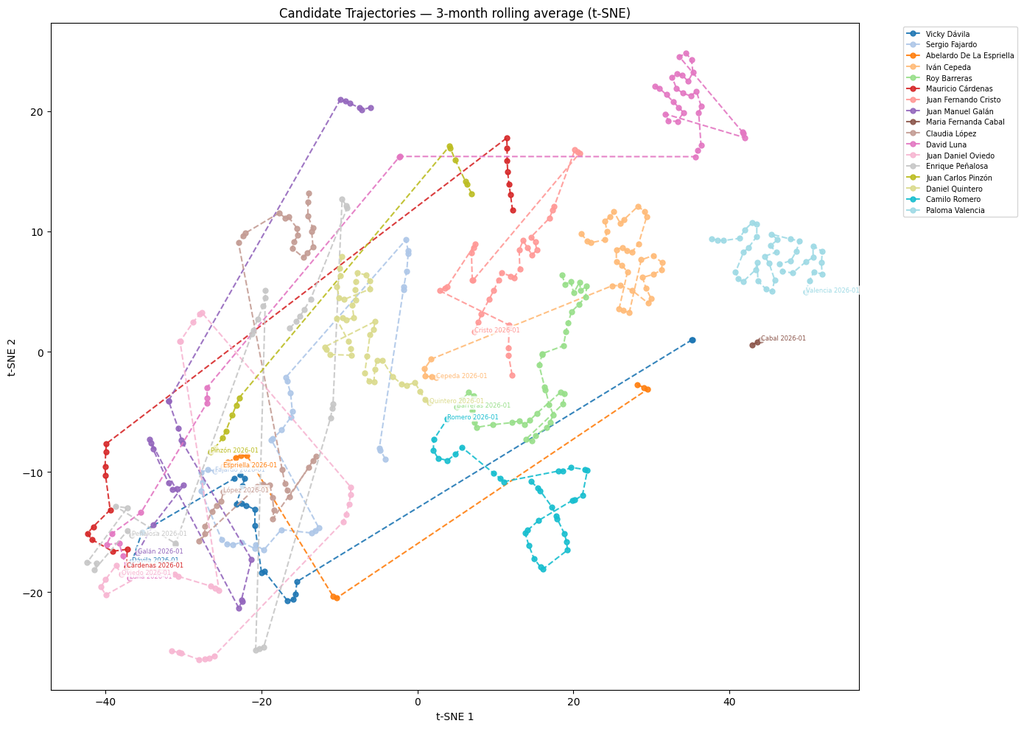

```python
plot_trajectories(monthly_alc, title='Candidate Trajectories — 3-month rolling average (t-SNE)')
```

This is much more informative than a static representation of the global model. Let's try to make sense of some trajectories.

### Coalitions and meaning convergence

Looking at where candidates end up at the end of the period, we can pretty easily infer the two clusters of candidates representing the two most competitive consults. We see a convergence in semantic trajectories from candidates in the left (Camilo Romero, Roy Barreras, Daniel Quintero, Iván Cepeda and Juan Fernando Cristo) around the center of the plot, and a big convergence of candidates in the center-right (Juan Manuel Oviedo, Vicky Dávila, Juan Manuel Galán, Mauricio Cárdenas, and David Luna) in the bottom-left of the plot. In both cases, the candidate word vectors are close to each other in the final month that I have data on, but we can see that this convergence is not random but the result of a month-by-month trajectory.

The technocratic centrists, Sergio Fajardo and Claudia Lopez, also end up close together in semantic space. There were rumors about them going into a consult that ended up not happening, but we can see the results of media speculation in the plot.

### Semantic leaps and becoming a candidate

I have a harder time interpreting some of the massive shifts in position that we see from a couple of candidates. Interestingly enough, all jumps seem to be moving in a similar direction. There are probably methods out there to infer an interpretation of the dimension but this post is long enough. If we consider that most of the candidates that "leap" occupied very specific and prominent roles in the landscape at the beginning of the period, where the presidential candidacies are not a determinant factor.

In this theory, candidates move a different region in the meaning space to a more generic "candidate" meaning space. Vicky Dávila and Abelardo de la Espriella go from prominent outsider to the candidate region, while David Luna and Iván Cépeda go from being senators to candidates. I feel particularly good about the senator region interpretation as we see both Paloma Valencia and Maria Fernanda Cabal around there. The data scrapping was done before Paloma Valencia became the official candidate of the right-wing party Centro Democrático, so maybe if were to get more data we would see a similar leap.

### Abelardo de la Espriella

He is the biggest story in this electoral cycle. A controversial lawyer following the playbook of the Milei, Bukele and other latin american neolibertarians. Big on AI, performative masculinity and harrasing journalists. Like with many unapologetic, right-wing outsiders, the media does not know what to do with him.

In his case, we are only interested in the later part of the period, few expected him to be a presidential front runner in august 2022. His leap into the candidate semantic region is logical in that sense, but being that close to Sergio Fajardo and Claudia Lopez, who have openly distanced themselves from him, is weird.

Maybe the ALC embeddings are able to capture the hard time that traditional news media, such as El Espectador have when trying to conceptualize this type character.